# Lecture 1: Planning an Analysis

Author

Affiliation

Max Griswold

Pardee RAND Graduate School

Published

January 8, 2024

## The purpose of this class

- Most researchers learn to conduct quantitative analyses through apprenticeship.
- However, we can do better analyses if we follow a set of building blocks and interrogate our research designs.
- The purpose of this class is to learn skills to improve our analyses and to practice doing an analysis of our own.

## Learning objectives

By the end of the quarter, you should be able to:

- Evaluate the strength and weaknesses of a quantitative research design.
- Provide effective feedback and comments to other researchers on their research design.
- Implement a exploratory or causal analysis using R code.

## Course format

Lecture days:

- Learn skills and resources to execute a research design.
- Learn how to use R to conduct an analysis.

Workshop days:

- Share our code in small groups.
- Present results from interim work.
- Discuss strengths and weakness of published papers.

## Class resources

[Class Github page](https://github.com/maxgriswold/Quantitative-Analysis-Practicum-2024)

[figure not shown]

Gelman, Hill, and Vehtari, 2022

[figure not shown]

Blair, Coppock, and Humphreys, 2023

## Planning an analysis

**Robustness:**  
Will my research design provide a reliable answer?

**Feasability:**  
Is my research question answerable given my constraints?

**Relevancy:**  
Is this a meaningful question to ask and who is the audience?

Relevancy is particularly important for policy analysis!

## Robustness

- An analysis is only useful if the results are reliable (unbiased and precise).
- Our research design determines how much trust we can place in the estimates we develop.
- To determine if our design is robust, we start with a theory of how the world is working.
- For an exploratory analysis, we need to use theory to think critically about measurement. For a causal analysis, we also need to think about the research design.

## Robustness - Generating a theory

Causal pathway diagrams allow us to visualize our theory and begin to develop a design plan.

[figure not shown]

- We want to know how D effects Y.
- We might also be interested in how M changes the effect of D.
- We need to remove X from our model.
- We need to make sure we don’t condition on K.

## Robustness - Generating a theory

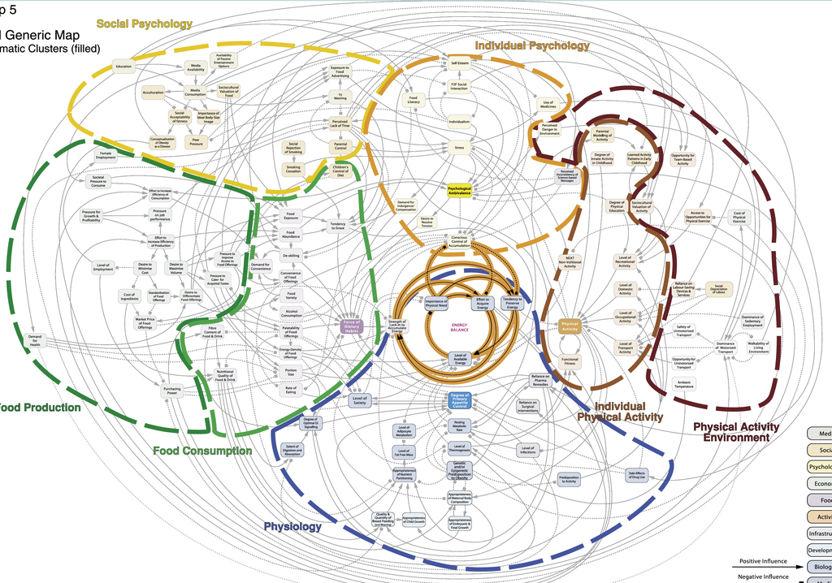

## Robustness - Generating a theory

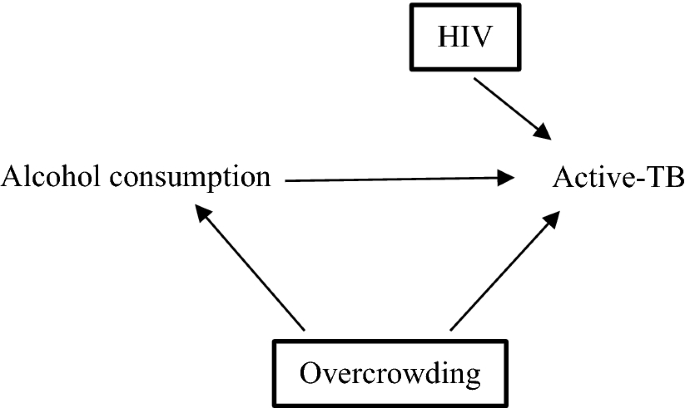

## Robustness - Testing a theory

Using our theory, we can try to determine an accurate data strategy (measurement) and an answer strategy (design) to test our research question.

[figure not shown]

## Feasibility

- Our research questions need to be scoped so we can answer them given available time and funding.
- To determine if our question is feasible, we need to use project management tools to evaluate if our time and resources will be enough to meet the needs of the project.
- Alternatively, we can scope our research question to fit our available resources

## Feasibility - Plan out the steps

Try working back from then end of the study (the estimate) to the necessary methods and data needed to obtain that result.

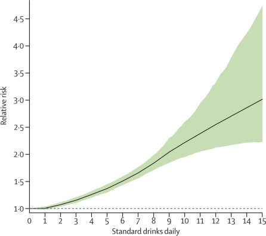

## Feasibility - Plan out the steps

Flowcharts can be used to plan out analysis steps and also serve as a useful rhetorical tool.

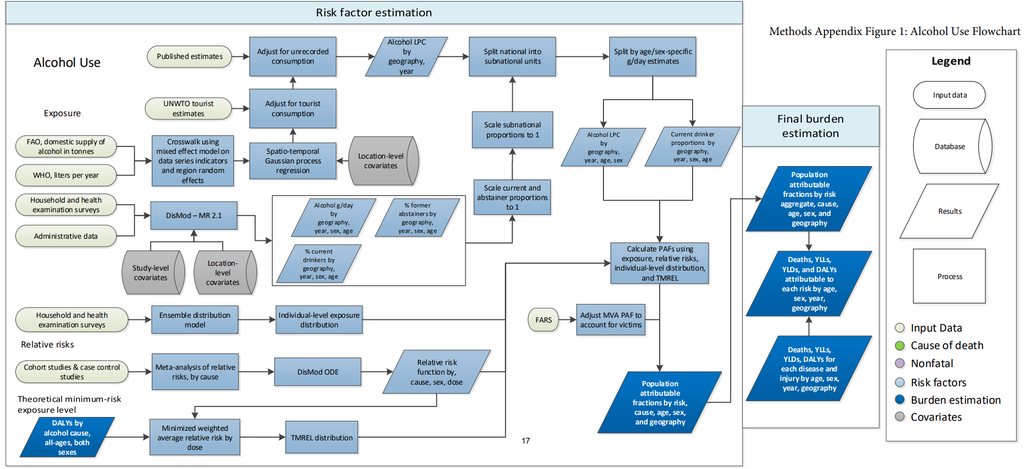

## Feasibility - Plan out the steps

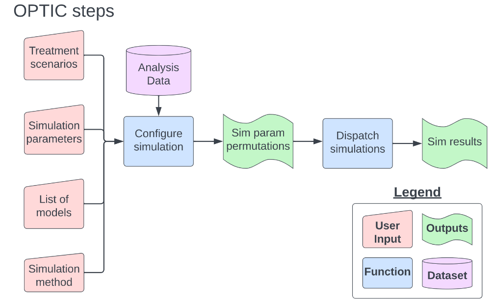

## Feasibility - Planning out time

Gantt charts provide an intuitive way to plan out timing.

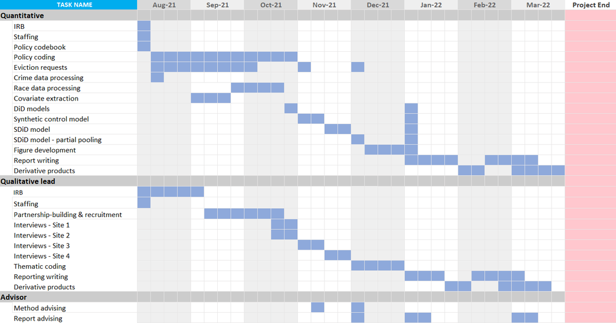

## Feasibility - Planning out budget

Use a a [budget estimator](https://randus.sharepoint.com/:x:/r/research/rfo/_layouts/15/Doc.aspx?sourcedoc=%7BF2E4FDF3-5589-4165-8C5E-E18ABE5ABE98%7D&file=estimator-tool.xlsm&action=default&mobileredirect=true&DefaultItemOpen=1) adapted to your schedule and products.

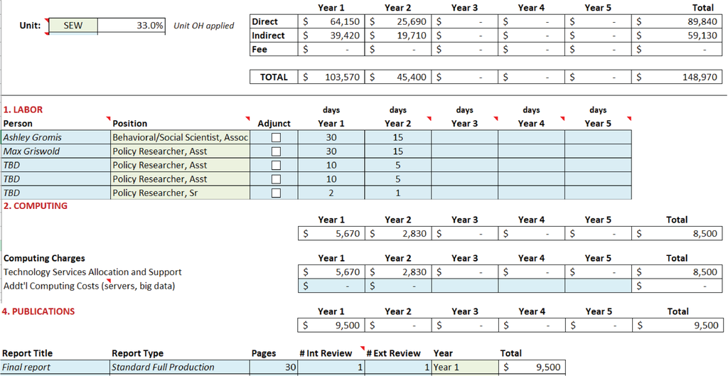

## Feasibility - Scoping questions

*If you think about it, specificity is also an act of shrewdness. A survey of 40 years of literature is vulnerable to all kinds of objections*

*The subject of “Gealogy,” for instance, is much too broad a topic. “Vulcanology” as a branch of geology, is still too comprehensive. “Volcanoes in Mexico” might be developed into a good but superficial paper. However, a further limitation to “The History of Popocateptl” (which one of Cortéz’s conquistadores probably climbed in 1519 and which erupted violently as late as 1702) would make for a more valuable study. Another limited topic, spanning fewer years, would be “The Birth and Apparent Death of Paricutin”*

*Here, I would suggest the last topic, but only if the [PhD] candidate really says all there is to say about that damned volcano.*

-Eco, 1977

- Limit the geography or time-periods of the study.
- Study less outcomes.
- Use a simpler method.
- Stratify fewer variables.

## Relevancy - Generating questions

Figuring out impactful research questions seems to be an art; here’s some starting points I’ve found useful:

- Be an informed citizen and policy observer.
- Look out for methodological shortcomings in previous work.
- Ask for feedback on ideas constantly (and not just from researchers)

## Relevancy - Generating impact

Think critically about who will care about the results and how the results will be used:

- Who is the audience for the study’s results?
- How will a decision-maker use these results?
- What are the policy-levers available to the decision-maker?

## Relevancy - Disseminating results

Your results are only useful if they get to the right audience. Start thinking about how your results will be disseminated at the beginning of your project!

- Start writing up your research article at the beginning. Good writing takes time.
- Think through how you’ll describe results if the study’s hypothesis is confirmed. But also think through how the results will be useful if the hypothesis is rejected.
- Set up multiple plans to disseminate results beyond a research article.

## Next class

For class on Wednesday, please prepare the following:

- A short elevator-pitch for your research
  - No longer than 1-2 minutes.
  - What is your research question?
  - What data will you use to answer your question?
  - What research design do you plan to use?
  - Who will use the results of your analysis?
- Read the [Tong, 2019](https://github.com/maxgriswold/Quantitative-Analysis-Practicum-2024/blob/main/readings/week_1/tong_2019.pdf) paper.
  - What arguments did you find convincing/unconvincing and why?
- Download [Rstudio](https://posit.co/download/rstudio-desktop/) and [GitHub desktop](https://desktop.github.com/).
  - You might need to ask IS for permission to install these programs.
  - Try loading your data into R and begin investigating your dataset.